# R Notebook

This is an [R Markdown] Notebook examining media house value (medv) per the example in Chapter 3.6.2 of “An Introduction to Statistical Learning” (James, Witten, Hastie & Tibshirani).

First, we read in the required libraries: MASS and ISLR. ISLR contains the datasets used in the aforementioned textbook.

```r
library(MASS)
library(ISLR)
```

We are going to try to predict median home value using 13 predictors in the “Boston” dataset from the MASS library. We use the fix command to fix the dataset, and then use the “names” function to retrieve the feature names.

```r
fix(Boston)
names(Boston)
```

```
 [1] "crim"    "zn"      "indus"   "chas"    "nox"     "rm"      "age"     "dis"     "rad"     "tax"     "ptratio" "black"
[13] "lstat"   "medv"
```

Check the distribution of median home values first:

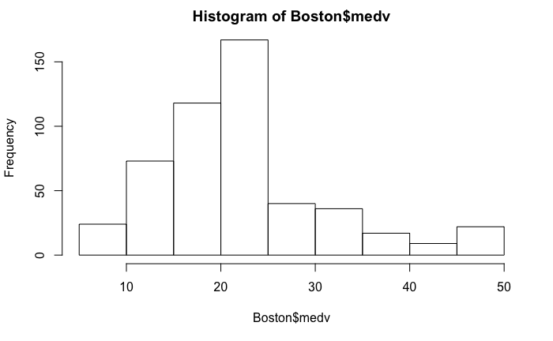

```r
hist(Boston$medv)
```

We start by performing a linear (least squares) regression using the lm() function. We first create a model using lstat (the % households with a low socioeconomic status) as the sole predictor.

```r
lm.fit=lm(medv~lstat, data=Boston)
#print out some of the basic info about the model lm.fit
lm.fit
```

```
Call:
lm(formula = medv ~ lstat, data = Boston)

Coefficients:
(Intercept)        lstat
      34.55        -0.95
```

To get more information about this model, we do the following:

```r
summary(lm.fit)
```

```
Call:
lm(formula = medv ~ lstat, data = Boston)

Residuals:
    Min      1Q  Median      3Q     Max
-15.168  -3.990  -1.318   2.034  24.500

Coefficients:
            Estimate Std. Error t value Pr(>|t|)
(Intercept) 34.55384    0.56263   61.41   <2e-16 ***
lstat       -0.95005    0.03873  -24.53   <2e-16 ***
---
Signif. codes:  0 ‘***’ 0.001 ‘**’ 0.01 ‘*’ 0.05 ‘.’ 0.1 ‘ ’ 1

Residual standard error: 6.216 on 504 degrees of freedom
Multiple R-squared:  0.5441,    Adjusted R-squared:  0.5432
F-statistic: 601.6 on 1 and 504 DF,  p-value: < 2.2e-16
```

We can find the details about what pieces of information are in the lm.fit object by calling the names() function again:

```r
names(lm.fit)
```

```
 [1] "coefficients"  "residuals"     "effects"       "rank"          "fitted.values" "assign"        "qr"
 [8] "df.residual"   "xlevels"       "call"          "terms"         "model"
```

We can access any of these features using the notation lmfit$feature. For example:

```r
lm.fit$coefficients
```

```
(Intercept)       lstat
 34.5538409  -0.9500494
```

Observe the confidence intervals on the model’s intercept and slope using the confint() function:

```r
confint(lm.fit)
```

```
                2.5 %     97.5 %
(Intercept) 33.448457 35.6592247
lstat       -1.026148 -0.8739505
```

Furthermore, we can use the lm.fit model to make a prediction based on specified lstat values. For example,

```r
lstat_test = c(5,10,15)
predict(lm.fit, data.frame(lstat_test), interval="confidence")
```

[output not shown]

We can also plot the data:

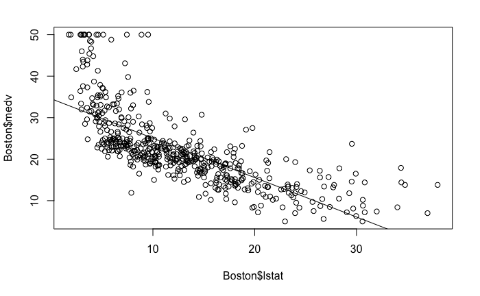

```r
plot(Boston$lstat,Boston$medv) #scatterplot of the data
abline(lm.fit) #draws the least squares line
```

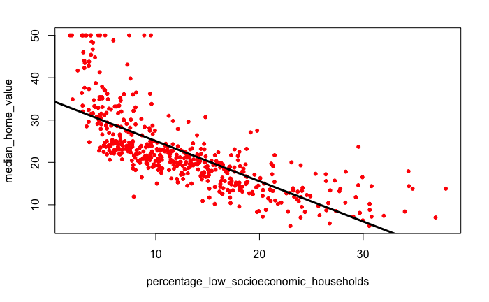

```r
#add some color to the plot
percentage_low_socioeconomic_households = Boston$lstat
median_home_value = Boston$medv
plot(percentage_low_socioeconomic_households,median_home_value, col="red", pch=20) #scatterplot of the data
abline(lm.fit, lwd=3) #draws the least squares line
```

Next, we take a look at some diagnostic plots associated with the model lm.fit:

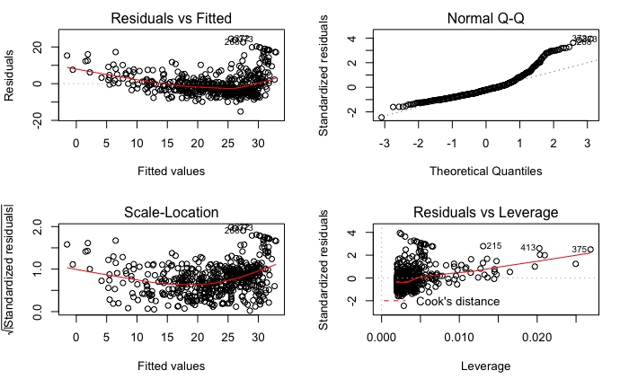

```r
par(mfrow=c(2,2))
plot(lm.fit)
```

We observe some non-linearity in this model based on the residuals plot (it is curved, not flat and evenly distributed). Next, we will try to improve the linear model by incorporating additional features. That will be in the next session.

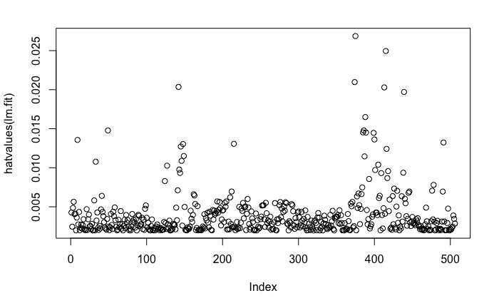

```r
plot(hatvalues(lm.fit))
```

```r
which.max(hatvalues(lm.fit))
```

```
375
375
```

Let’s add in the age independent variable to make a model with two predictors.

```r
lm.fit = lm(medv~lstat+age, data=Boston)
summary(lm.fit)
```

```
Call:
lm(formula = medv ~ lstat + age, data = Boston)

Residuals:
    Min      1Q  Median      3Q     Max
-15.981  -3.978  -1.283   1.968  23.158

Coefficients:
            Estimate Std. Error t value Pr(>|t|)
(Intercept) 33.22276    0.73085  45.458  < 2e-16 ***
lstat       -1.03207    0.04819 -21.416  < 2e-16 ***
age          0.03454    0.01223   2.826  0.00491 **
---
Signif. codes:  0 ‘***’ 0.001 ‘**’ 0.01 ‘*’ 0.05 ‘.’ 0.1 ‘ ’ 1

Residual standard error: 6.173 on 503 degrees of freedom
Multiple R-squared:  0.5513,    Adjusted R-squared:  0.5495
F-statistic:   309 on 2 and 503 DF,  p-value: < 2.2e-16
```

Now we can try fitting a model with all 13 variables:

```r
lm.fit=lm(medv~., data=Boston)
summary(lm.fit)
```

```
Call:
lm(formula = medv ~ ., data = Boston)

Residuals:
    Min      1Q  Median      3Q     Max
-15.595  -2.730  -0.518   1.777  26.199

Coefficients:
              Estimate Std. Error t value Pr(>|t|)
(Intercept)  3.646e+01  5.103e+00   7.144 3.28e-12 ***
crim        -1.080e-01  3.286e-02  -3.287 0.001087 **
zn           4.642e-02  1.373e-02   3.382 0.000778 ***
indus        2.056e-02  6.150e-02   0.334 0.738288
chas         2.687e+00  8.616e-01   3.118 0.001925 **
nox         -1.777e+01  3.820e+00  -4.651 4.25e-06 ***
rm           3.810e+00  4.179e-01   9.116  < 2e-16 ***
age          6.922e-04  1.321e-02   0.052 0.958229
dis         -1.476e+00  1.995e-01  -7.398 6.01e-13 ***
rad          3.060e-01  6.635e-02   4.613 5.07e-06 ***
tax         -1.233e-02  3.760e-03  -3.280 0.001112 **
ptratio     -9.527e-01  1.308e-01  -7.283 1.31e-12 ***
black        9.312e-03  2.686e-03   3.467 0.000573 ***
lstat       -5.248e-01  5.072e-02 -10.347  < 2e-16 ***
---
Signif. codes:  0 ‘***’ 0.001 ‘**’ 0.01 ‘*’ 0.05 ‘.’ 0.1 ‘ ’ 1

Residual standard error: 4.745 on 492 degrees of freedom
Multiple R-squared:  0.7406,    Adjusted R-squared:  0.7338
F-statistic: 108.1 on 13 and 492 DF,  p-value: < 2.2e-16
```

Check the R-squared value in the model.

```r
summary(lm.fit)$r.sq
```

```
[1] 0.7406427
```

Check the residual standard error (RSE) (note that this measure is in the units of y (median home value in thousands of dollars):

```r
summary(lm.fit)$sigma
```

```
[1] 4.745298
```

We can check the variance inflation factor (VIF) for each feature to check for multicolinearity. This function is available through the car library.

```r
library(car)
vif(lm.fit)
```

```
    crim       zn    indus     chas      nox       rm      age      dis      rad      tax  ptratio    black    lstat
1.792192 2.298758 3.991596 1.073995 4.393720 1.933744 3.100826 3.955945 7.484496 9.008554 1.799084 1.348521 2.941491
```

Test out a new model using lstat, age, and lstat x age as predictors:

```r
lm.fit1 = lm(medv~lstat*age, data=Boston)
summary(lm.fit1)
```

```
Call:
lm(formula = medv ~ lstat * age, data = Boston)

Residuals:
    Min      1Q  Median      3Q     Max
-15.806  -4.045  -1.333   2.085  27.552

Coefficients:
              Estimate Std. Error t value Pr(>|t|)
(Intercept) 36.0885359  1.4698355  24.553  < 2e-16 ***
lstat       -1.3921168  0.1674555  -8.313 8.78e-16 ***
age         -0.0007209  0.0198792  -0.036   0.9711
lstat:age    0.0041560  0.0018518   2.244   0.0252 *
---
Signif. codes:  0 ‘***’ 0.001 ‘**’ 0.01 ‘*’ 0.05 ‘.’ 0.1 ‘ ’ 1

Residual standard error: 6.149 on 502 degrees of freedom
Multiple R-squared:  0.5557,    Adjusted R-squared:  0.5531
F-statistic: 209.3 on 3 and 502 DF,  p-value: < 2.2e-16
```

We can also try to use non-linear transformations of the predictors in our model. For example, we can create a quadratic predictor.

```r
lm.fit2 = lm(medv~lstat+I(lstat^2), data=Boston)
summary(lm.fit2)
```

```
Call:
lm(formula = medv ~ lstat + I(lstat^2), data = Boston)

Residuals:
     Min       1Q   Median       3Q      Max
-15.2834  -3.8313  -0.5295   2.3095  25.4148

Coefficients:
             Estimate Std. Error t value Pr(>|t|)
(Intercept) 42.862007   0.872084   49.15   <2e-16 ***
lstat       -2.332821   0.123803  -18.84   <2e-16 ***
I(lstat^2)   0.043547   0.003745   11.63   <2e-16 ***
---
Signif. codes:  0 ‘***’ 0.001 ‘**’ 0.01 ‘*’ 0.05 ‘.’ 0.1 ‘ ’ 1

Residual standard error: 5.524 on 503 degrees of freedom
Multiple R-squared:  0.6407,    Adjusted R-squared:  0.6393
F-statistic: 448.5 on 2 and 503 DF,  p-value: < 2.2e-16
```

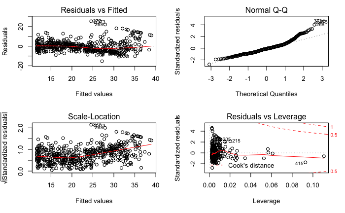

```r
par(mfrow=c(2,2))
plot(lm.fit2)
```

The residuals seem flat and without a trend/pattern. This indicates that the quadratic term addition resulted in a better fit.